# DF-test

Boyko Amarov

1/4/2022

ARIMA(p, d, q)

```r
library(urca)
```

Random walk model without a drift

$$y_{t} = y_{t - 1} + e_{t}, e_t \sim WN(\sigma^2)\\
\Delta y_{t} = y_{t} - y_{t - 1} = e_{t}\\
f' = \lim_{\epsilon \to 0}\frac{f(x) - f(x + \epsilon)}{\epsilon}$$

$$\lambda - 1 = 0 \implies
\lambda^* = 1$$

The solution of this characteristic equation is 1. We say that the characteristic equation has a unit root.

ARIMA(0, 1, 0)

## Random walks simulation

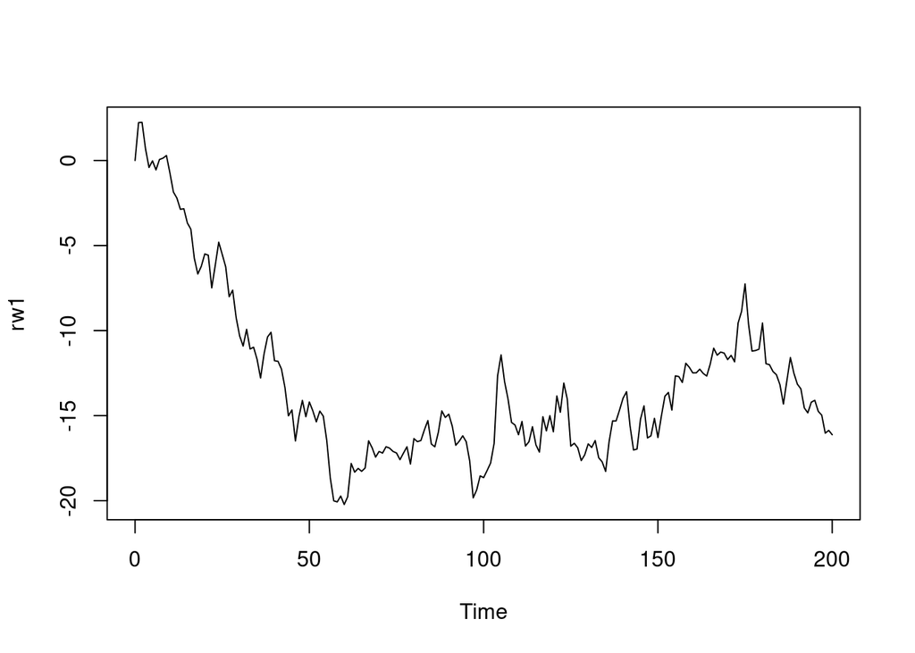

```r
rw1 <- arima.sim(model = list(order = c(0, 1, 0)), n = 200)
rw2 <- arima.sim(model = list(order = c(0, 1, 0)), n = 200)

# rw2 <- 1.5 * rw1 + rnorm(n = 200)
plot(rw1)
```

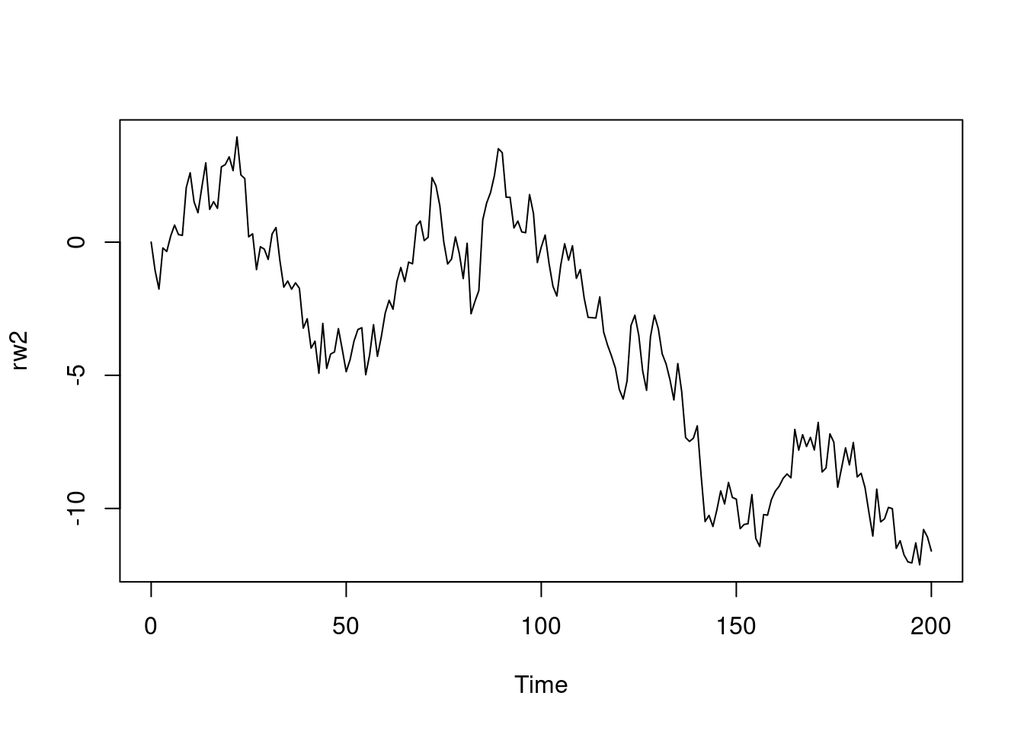

```r
plot(rw2)
```

```r
summary(lm(rw2 ~ rw1))
```

```
##
## Call:
## lm(formula = rw2 ~ rw1)
##
## Residuals:
##    Min     1Q Median     3Q    Max
## -8.037 -4.387  1.024  3.368  7.713
##
## Coefficients:
##             Estimate Std. Error t value Pr(>|t|)
## (Intercept) -1.30807    0.87034  -1.503  0.13444
## rw1          0.19164    0.06213   3.084  0.00233 **
## ---
## Signif. codes:  0 '***' 0.001 '**' 0.01 '*' 0.05 '.' 0.1 ' ' 1
##
## Residual standard error: 4.338 on 199 degrees of freedom
## Multiple R-squared:  0.04562,    Adjusted R-squared:  0.04083
## F-statistic: 9.513 on 1 and 199 DF,  p-value: 0.00233
```

Regression model

$$y_{t}: \text{ random walk 2}\\
x_{t}: \text{ random walk 1}\\
y_{t} = \beta_0 + \beta_1 x_{t} + e_{t}, e_{t} \sim N(0, \sigma^2)$$
Estimated regression equation

$$H_0: \beta_1 = 0\\
H_1: \beta_1 \neq 0$$
We reject the null hypothesis if the p-value of the test is less than 0.05 (convention).

spurious regression

# Unit root tests

AR(1) process without a constant

$$y_{t} = \alpha_1 y_{t - 1} + e_{t}, e_t \sim WN(\sigma^2)$$
If the process has a unit root, it follows that $\alpha_1 = 1$.

We would like to test the hypothesis:

$$H_0: \alpha_1 = 1\\
H_1: \alpha_1 < 1$$

The first difference of the random walk process is stationary, because it is simply equal to the pure random process $e_{t}$ and it is stationary by the properties of the pure random process. We say that the process (in this case the random walk process) is integrated of order 1.

## Dickey-Fuller Unit Root Test

$$y_{t} - y_{t - 1} = \alpha_1 y_{t - 1} + e_{t} - y_{t - 1} \\
\iff\\
\Delta y_{t} = (\alpha_1 - 1)y_{t - 1} + e_t$$
$$\alpha_1 - 1 = 0 \iff \alpha_1 = 1$$

We can use the t-statistic for testing the hypothesis that the coefficient of $y_{t - 1}$ equals 0, but the distribution of this statistic under the $H_0$ (assuming that $\alpha_1 = 1$) is not a t-distribution. Therefore, we need to use special critical values in order to perform the test.

```r
summary(ur.df(rw1, type = "none", lags = 0))
```

```
##
## ###############################################
## # Augmented Dickey-Fuller Test Unit Root Test #
## ###############################################
##
## Test regression none
##
##
## Call:
## lm(formula = z.diff ~ z.lag.1 - 1)
##
## Residuals:
##     Min      1Q  Median      3Q     Max
## -2.7469 -0.7329 -0.0822  0.4921  3.9805
##
## Coefficients:
##          Estimate Std. Error t value Pr(>|t|)
## z.lag.1 0.0005781  0.0052457    0.11    0.912
##
## Residual standard error: 1.038 on 199 degrees of freedom
## Multiple R-squared:  6.102e-05,  Adjusted R-squared:  -0.004964
## F-statistic: 0.01214 on 1 and 199 DF,  p-value: 0.9124
##
##
## Value of test-statistic is: 0.1102
##
## Critical values for test statistics:
##       1pct  5pct 10pct
## tau1 -2.58 -1.95 -1.62
```

-1 in the regression formula instructs lm to exclude the intercept from the regression equation.

$$\underbrace{\Delta y_{t}}_{z.diff} = \underbrace{y_{t - 1}}_{z.lag.1} +
e_t$$
t-value is the value of the t-statistic.

```
  1pct  5pct 10pct
```

tau1 -2.58 -1.95 -1.62

and we reject the null hypothesis if the t-value value is lower than the critical values.

$$H_0: \alpha_1 - 1 = 0$$

## Simulation 2: Stationary AR(1) with zero level

$$y_{t} = 0.7y_{t - 1} + e_{t}, e_t \sim WN(1)$$

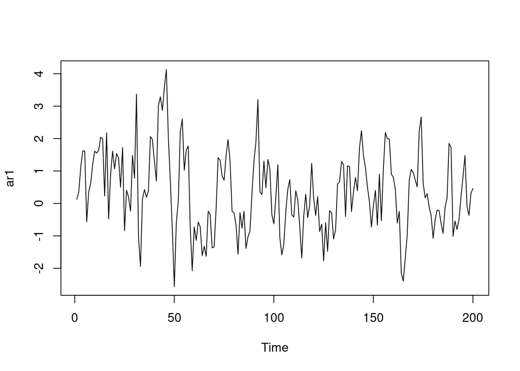

```r
set.seed(5445)
ar1 <- arima.sim(n = 200, model = list(ar = 0.7))
plot(ar1)
```

```r
summary(ur.df(ar1, type = "none", lags = 0))
```

```
##
## ###############################################
## # Augmented Dickey-Fuller Test Unit Root Test #
## ###############################################
##
## Test regression none
##
##
## Call:
## lm(formula = z.diff ~ z.lag.1 - 1)
##
## Residuals:
##     Min      1Q  Median      3Q     Max
## -3.1957 -0.4637  0.1847  0.7274  2.8661
##
## Coefficients:
##         Estimate Std. Error t value Pr(>|t|)
## z.lag.1 -0.35559    0.05437   -6.54 5.12e-10 ***
## ---
## Signif. codes:  0 '***' 0.001 '**' 0.01 '*' 0.05 '.' 0.1 ' ' 1
##
## Residual standard error: 0.981 on 198 degrees of freedom
## Multiple R-squared:  0.1776, Adjusted R-squared:  0.1735
## F-statistic: 42.77 on 1 and 198 DF,  p-value: 5.122e-10
##
##
## Value of test-statistic is: -6.5401
##
## Critical values for test statistics:
##       1pct  5pct 10pct
## tau1 -2.58 -1.95 -1.62
```

-6.54 < -2.58 < -1.95 => reject the null hypothesis of presence of a unit root

## Simulation 2: Stationary AR(1) with non-zero level

$$y_{t} = 100 + 0.7y_{t - 1} + e_{t}, e_t \sim WN(1)$$

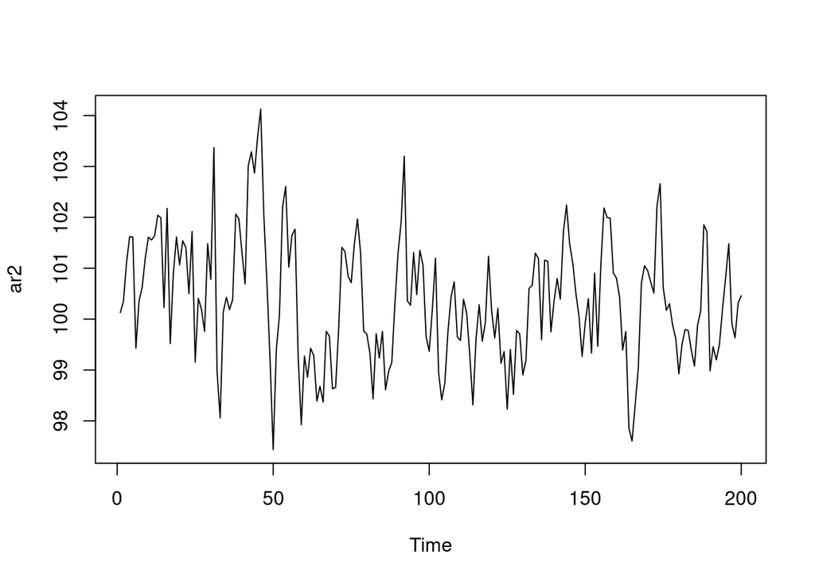

```r
ar2 <- 100 + ar1
plot(ar2)
```

```r
summary(ur.df(ar2, type = "none", lags = 0))
```

```
##
## ###############################################
## # Augmented Dickey-Fuller Test Unit Root Test #
## ###############################################
##
## Test regression none
##
##
## Call:
## lm(formula = z.diff ~ z.lag.1 - 1)
##
## Residuals:
##     Min      1Q  Median      3Q     Max
## -4.3897 -0.5694 -0.0054  0.6735  2.5924
##
## Coefficients:
##           Estimate Std. Error t value Pr(>|t|)
## z.lag.1 -4.129e-05  7.640e-04  -0.054    0.957
##
## Residual standard error: 1.082 on 198 degrees of freedom
## Multiple R-squared:  1.475e-05,  Adjusted R-squared:  -0.005036
## F-statistic: 0.00292 on 1 and 198 DF,  p-value: 0.957
##
##
## Value of test-statistic is: -0.054
##
## Critical values for test statistics:
##       1pct  5pct 10pct
## tau1 -2.58 -1.95 -1.62
```

```r
summary(ur.df(ar2, type = "drift", lags = 0))
```

```
##
## ###############################################
## # Augmented Dickey-Fuller Test Unit Root Test #
## ###############################################
##
## Test regression drift
##
##
## Call:
## lm(formula = z.diff ~ z.lag.1 + 1)
##
## Residuals:
##     Min      1Q  Median      3Q     Max
## -3.2327 -0.6111  0.0591  0.6185  2.7507
##
## Coefficients:
##             Estimate Std. Error t value Pr(>|t|)
## (Intercept) 38.72772    5.64276   6.863 8.54e-11 ***
## z.lag.1     -0.38589    0.05622  -6.863 8.53e-11 ***
## ---
## Signif. codes:  0 '***' 0.001 '**' 0.01 '*' 0.05 '.' 0.1 ' ' 1
##
## Residual standard error: 0.9742 on 197 degrees of freedom
## Multiple R-squared:  0.193,  Adjusted R-squared:  0.1889
## F-statistic: 47.11 on 1 and 197 DF,  p-value: 8.529e-11
##
##
## Value of test-statistic is: -6.8635 23.554
##
## Critical values for test statistics:
##       1pct  5pct 10pct
## tau2 -3.46 -2.88 -2.57
## phi1  6.52  4.63  3.81
```

```
  1pct  5pct 10pct
```

tau2 -3.46 -2.88 -2.57

## Simulation 3 (Stationary AR(1) with trend)

$$y_{t} = 10 + 0.1t + 0.7 y_{t - 1} + e_{t}$$

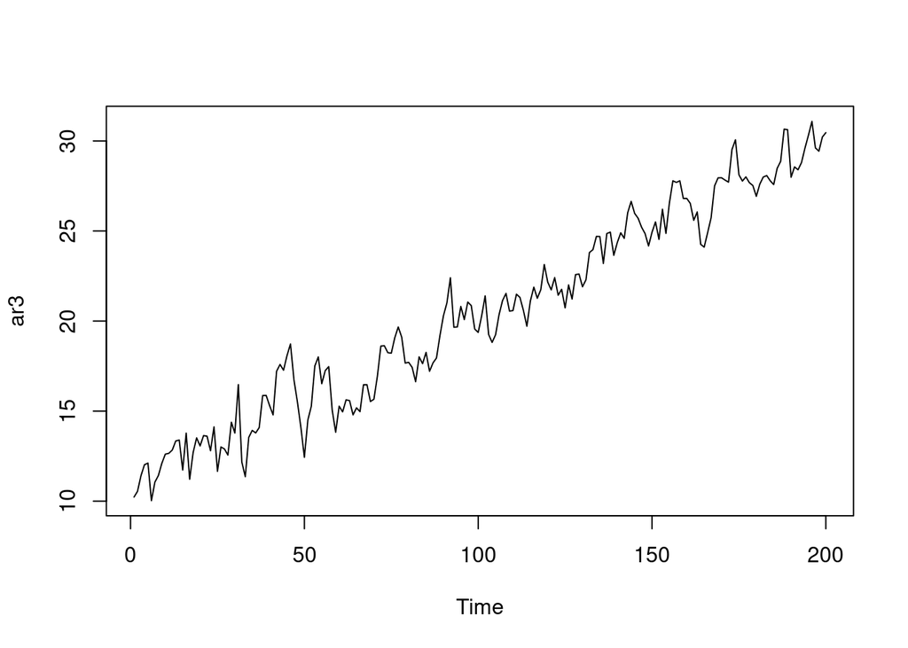

```r
ar3 <- 10 + 0.1*(1:length(ar1)) + ar1
plot(ar3)
```

```r
summary(ur.df(ar3, type = "drift", lags = 0))
```

```
##
## ###############################################
## # Augmented Dickey-Fuller Test Unit Root Test #
## ###############################################
##
## Test regression drift
##
##
## Call:
## lm(formula = z.diff ~ z.lag.1 + 1)
##
## Residuals:
##     Min      1Q  Median      3Q     Max
## -4.4678 -0.5735  0.0574  0.6901  2.4643
##
## Coefficients:
##             Estimate Std. Error t value Pr(>|t|)
## (Intercept)  0.48017    0.28721   1.672   0.0961 .
## z.lag.1     -0.01859    0.01360  -1.367   0.1731
## ---
## Signif. codes:  0 '***' 0.001 '**' 0.01 '*' 0.05 '.' 0.1 ' ' 1
##
## Residual standard error: 1.079 on 197 degrees of freedom
## Multiple R-squared:  0.0094, Adjusted R-squared:  0.004372
## F-statistic: 1.869 on 1 and 197 DF,  p-value: 0.1731
##
##
## Value of test-statistic is: -1.3673 1.8173
##
## Critical values for test statistics:
##       1pct  5pct 10pct
## tau2 -3.46 -2.88 -2.57
## phi1  6.52  4.63  3.81
```

```r
summary(ur.df(ar3, type = "trend", lags = 0))
```

```
##
## ###############################################
## # Augmented Dickey-Fuller Test Unit Root Test #
## ###############################################
##
## Test regression trend
##
##
## Call:
## lm(formula = z.diff ~ z.lag.1 + 1 + tt)
##
## Residuals:
##     Min      1Q  Median      3Q     Max
## -3.3040 -0.6054  0.0831  0.5956  2.6345
##
## Coefficients:
##              Estimate Std. Error t value Pr(>|t|)
## (Intercept)  4.446414   0.632991   7.024 3.46e-11 ***
## z.lag.1     -0.402536   0.057255  -7.031 3.34e-11 ***
## tt           0.038493   0.005608   6.865 8.57e-11 ***
## ---
## Signif. codes:  0 '***' 0.001 '**' 0.01 '*' 0.05 '.' 0.1 ' ' 1
##
## Residual standard error: 0.9716 on 196 degrees of freedom
## Multiple R-squared:  0.2014, Adjusted R-squared:  0.1933
## F-statistic: 24.71 on 2 and 196 DF,  p-value: 2.681e-10
##
##
## Value of test-statistic is: -7.0306 17.2027 24.7148
##
## Critical values for test statistics:
##       1pct  5pct 10pct
## tau3 -3.99 -3.43 -3.13
## phi2  6.22  4.75  4.07
## phi3  8.43  6.49  5.47
```

```
  1pct  5pct 10pct
```

tau3 -3.99 -3.43 -3.13

## ADF-Test

Let us consider an AR(2) process

$$y_{t} = \alpha_1 y_{t - 1} + \alpha_2 y_{t - 2} + e_t$$

If this process has a unit root, then its characteristic equation

$$\lambda ^2 - \alpha_1 \lambda - \alpha_2 = 0$$

has a solution $\lambda^{*} = 1$, therefore, setting $\lambda = 1$ satisfies the equation, and we obtain:

$$1^2 - \alpha_1 - \alpha_2 = 0$$

Therefore, if the process has a unit root, its coefficients sum to one. This is a hypothesis that we can test using data. Following the approach of the DF-Test, we can try to construct a regression equation where one of the coefficients is $1 - \alpha_1 - \alpha_2$. Then we can conduct a test of the null hypothesis that this coefficient is zero.

It turns out that we can reparemetrize the AR(2) model to obtain such an equation:

$$\begin{align}
y_{t} - y_{t - 1} & = \alpha_1 y_{t - 1} - y_{t - 1} + \alpha_2 y_{t
- 2} + e_t\\
\Delta y_{t} & = (\alpha_1 - 1)y_{t - 1} + \alpha_2 y_{t - 2} +
e_t\\
\Delta y_{t} & = (\alpha_1 - 1)y_{t - 1} + \alpha_2 y_{t - 1} -
\alpha_2 y_{t - 1} + \alpha_2 y_{t - 2} + e_t\\
\Delta y_{t} & = (\alpha_1 + \alpha_2 - 1)y_{t - 1} - \alpha_2 y_{t
- 1} \alpha_2 y_{t - 2} + e_t\\
\Delta y_{t} & = (\alpha_1 + \alpha_2 - 1)y_{t - 1} - \alpha_2(y_{t
- 1} - y_{t - 2}) + e_t\\
\Delta y_{t} & = (\alpha_1 + \alpha_2 - 1)y_{t - 1} - \alpha_2\Delta
y_{t - 1} + e_t\\
\end{align}$$

In the general case of an AR(p) process the equation looks more complicated but it is derived in exactly the same way as for the AR(2) process:

$$\Delta y_t = (\rho - 1) y_{t - 1} + \theta_{1} \Delta y_{t - 1} +
\theta_2 \Delta y_{t - 2} + \ldots + \theta_{p - 1} \Delta y_{t - p + 1}
+ e_t$$

where $\rho$ and $\theta_i$ are defined as:

$$\rho = \sum_{j = 1}^p \alpha_j \\
\theta_i = - \sum_{j = i + 1}^{p} \alpha_j$$

## Simulation: AR(3)

$$y_t = 0.6y_{t - 1} + 0.4y_{t - 2} - 0.7y_{t - 2} + e_t, e_t \sim WN(1)$$

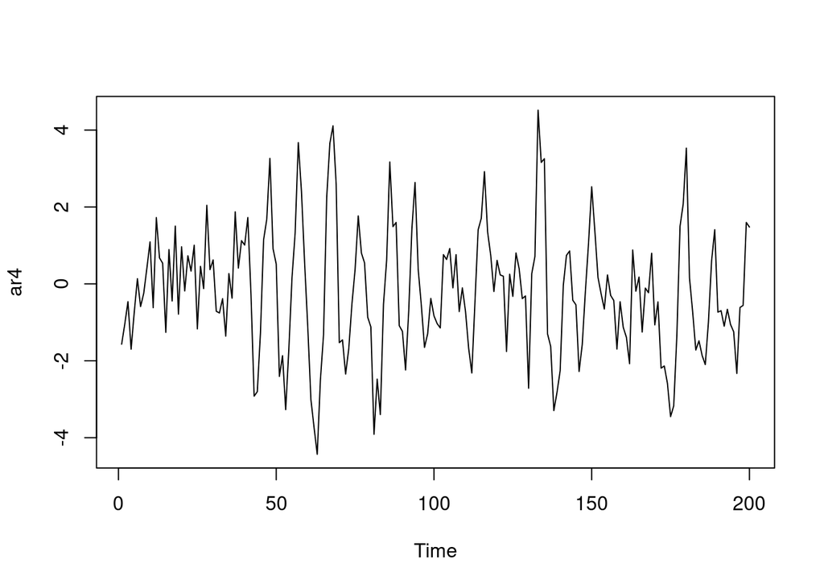

```r
set.seed(521)
ar4 <- arima.sim(n = 200, model = list(ar = c(0.6, 0.4, -0.7)))
plot(ar4)
```

```r
summary(ur.df(ar4, type = "none", lags = 0))
```

```
##
## ###############################################
## # Augmented Dickey-Fuller Test Unit Root Test #
## ###############################################
##
## Test regression none
##
##
## Call:
## lm(formula = z.diff ~ z.lag.1 - 1)
##
## Residuals:
##     Min      1Q  Median      3Q     Max
## -3.2994 -0.9389 -0.1619  0.8093  4.0805
##
## Coefficients:
##         Estimate Std. Error t value Pr(>|t|)
## z.lag.1 -0.38591    0.05607  -6.883 7.54e-11 ***
## ---
## Signif. codes:  0 '***' 0.001 '**' 0.01 '*' 0.05 '.' 0.1 ' ' 1
##
## Residual standard error: 1.302 on 198 degrees of freedom
## Multiple R-squared:  0.1931, Adjusted R-squared:  0.189
## F-statistic: 47.38 on 1 and 198 DF,  p-value: 7.543e-11
##
##
## Value of test-statistic is: -6.8832
##
## Critical values for test statistics:
##       1pct  5pct 10pct
## tau1 -2.58 -1.95 -1.62
```

```r
summary(ur.df(ar4, type = "none", selectlags = "AIC"))
```

```
##
## ###############################################
## # Augmented Dickey-Fuller Test Unit Root Test #
## ###############################################
##
## Test regression none
##
##
## Call:
## lm(formula = z.diff ~ z.lag.1 - 1 + z.diff.lag)
##
## Residuals:
##     Min      1Q  Median      3Q     Max
## -3.2490 -1.0398 -0.1433  0.7901  4.0562
##
## Coefficients:
##            Estimate Std. Error t value Pr(>|t|)
## z.lag.1    -0.44249    0.06223  -7.110 2.11e-11 ***
## z.diff.lag  0.14540    0.07070   2.057   0.0411 *
## ---
## Signif. codes:  0 '***' 0.001 '**' 0.01 '*' 0.05 '.' 0.1 ' ' 1
##
## Residual standard error: 1.294 on 196 degrees of freedom
## Multiple R-squared:  0.2096, Adjusted R-squared:  0.2016
## F-statistic: 25.99 on 2 and 196 DF,  p-value: 9.725e-11
##
##
## Value of test-statistic is: -7.1101
##
## Critical values for test statistics:
##       1pct  5pct 10pct
## tau1 -2.58 -1.95 -1.62
```

## KPSS Test

The KPSS test considers stationarity as the null hypothesis. Let’s consider the following process:

$$y_t = \alpha_t + \beta t + e_t, e_t \sim WN(\sigma^2)$$

where $\alpha_t$ is a random walk process: $\alpha_t = \alpha_{t - 1} + \epsilon_t$. If $y_t$ is trend-stationary (i.e. has no unit roots), then the variance of $\epsilon_t$ is zero (i.e. $\alpha_t$ is a constant process).

With the KPSS test we reject the null hypothesis (trend-stationarity) for *large* values of the test statistic.

```r
summary(ur.kpss(rw1))
```

```
##
## #######################
## # KPSS Unit Root Test #
## #######################
##
## Test is of type: mu with 4 lags.
##
## Value of test-statistic is: 1.2228
##
## Critical value for a significance level of:
##                 10pct  5pct 2.5pct  1pct
## critical values 0.347 0.463  0.574 0.739
```

```r
summary(ur.kpss(ar1))
```

```
##
## #######################
## # KPSS Unit Root Test #
## #######################
##
## Test is of type: mu with 4 lags.
##
## Value of test-statistic is: 0.398
##
## Critical value for a significance level of:
##                 10pct  5pct 2.5pct  1pct
## critical values 0.347 0.463  0.574 0.739
```